# Statistica I

Esame 17 Novembre 2023

Autore/Autrice

Affiliazione

Tommaso Rigon

DEMS

## Problema 1

I dati provengono da uno studio condotto da Charles Darwin nel 1875 riguardante i metodi di impollinazione. Un insieme di $n = 15$ coppie di piantine della stessa età, la prima ottenuta tramite impollinazione incrociata (*cross-fertilization*) e l’altra tramite auto-impollinazione (*self-fertilization*), sono state coltivate in condizioni quasi identiche.

I dati corrispondono alle altezze finali (in pollici) di ciascuna coppia di piante (`cross` e `self`), dopo un determinato periodo di tempo. La variabile `diff = cross - self` è pari alla differenza delle prime due variabili.

| Coppia | `cross` | `self` | `diff` |
| --- | --- | --- | --- |
| 1 | 23.500 | 17.375 | 6.125 |
| 2 | 12.000 | 20.375 | -8.375 |
| 3 | 21.000 | 20.000 | 1.000 |
| 4 | 22.000 | 20.000 | 2.000 |
| 5 | 19.125 | 18.375 | 0.750 |
| 6 | 21.500 | 18.625 | 2.875 |
| 7 | 22.125 | 18.625 | 3.500 |
| 8 | 20.375 | 15.250 | 5.125 |
| 9 | 18.250 | 16.500 | 1.750 |
| 10 | 21.625 | 18.000 | 3.625 |
| 11 | 23.250 | 16.250 | 7.000 |
| 12 | 21.000 | 18.000 | 3.000 |
| 13 | 22.125 | 12.750 | 9.375 |
| 14 | 23.000 | 15.500 | 7.500 |
| 15 | 12.000 | 18.000 | -6.000 |

Si è interessati a verificare se l’impollinazione incrociata consente alle piante di avere maggior vigore, misurata in termini di altezza.

1. Si calcolino medie e varianze delle variabili `cross` e `self`. Si calcoli quindi la media della variabile `diff`.
2. Si confrontino tra loro le distribuzioni `cross` e `self` tramite due *boxplot*, evidenziando la presenza di eventuali valori anomali. Si riportino i valori di mediana e quartili delle due distribuzioni.
3. Si stabilisca se le medie delle distribuzioni `cross` e `self` sono diverse tra loro, facendo uso di opportuni indici che tengano conto della variabilità dei dati. Si commentino i risultati nel contesto del problema.
4. Si disegni la funzione di ripartizione $F(\cdot)$ della variabile `diff`. Si calcoli il valore di $F(0)$ e si commenti il risultato nel contesto del problema.

**Schema della soluzione**

Statistiche descrittive delle variabili `cross`, `self` e `diff`.

```
##      Media cross  Media self Media diff Varianza cross Varianza self
## [1,]     20.19167     17.575   2.616667       12.21014       3.92875
```

Ulteriori statistiche descrittive per le variabili `cross` e `self`:

Primo quartile, mediana, terzo quartile della variabile `cross`

```
##    25%    50%    75%
## 19.125 21.500 22.125
```

Primo quartile, mediana, terzo quartile della variabile `self`

```
##    25%    50%    75%
## 16.250 18.000 18.625
```

Confronto tra i due boxplot, da cui è possibile notare la presenza di due outlier. Trattandosi di un confronto, i due boxplot andavano disegnati nello stesso grafico.

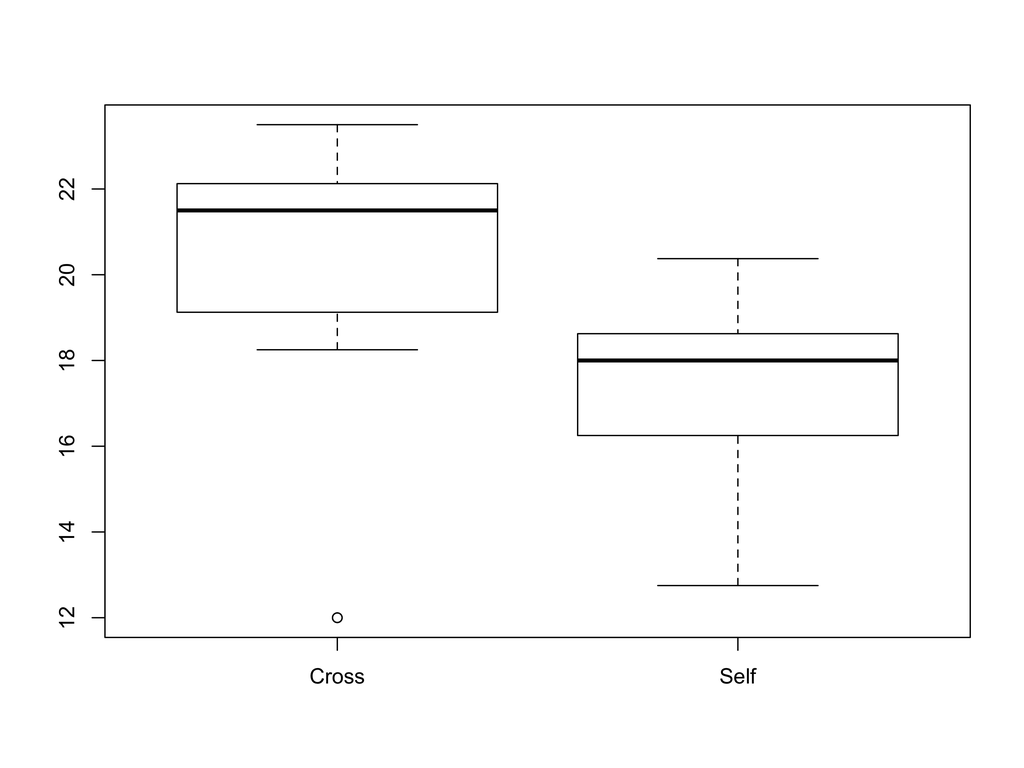

La dipendenza in media può essere misurata tramite l’indice $\eta^2$, il cui calcolo richiede alcuni passaggi intermedi. Era possibile far uso di appropriati indici alternativi non menzionati nel corso. Tuttavia, indici quali il coefficiente di variazione non misurano la dipendenza in media, bensì esclusivamente la variabilità dei dati.

Devianza entro i gruppi:

```
## [1] 242.0833
```

Devianza tra i gruppi:

```
## [1] 51.35208
```

Devianza totale:

```
## [1] 293.4354
```

Indice $\eta^2$ è quindi pari a:

```
## [1] 0.175003
```

Se ne deduce una lieve dipendenza in media, che a sua volta implica che il metodo di impollinazione incrociata consente alle piante di avere maggior vigore. Questo risultato sembra essere in parziale contraddizione con quanto mostrato dai boxplot, che evidenziano una dipendenza in distribuzione tra i due gruppi molto più marcata. È tuttavia possibile che $\eta^2$ sia relativamente basso a causa dei due outlier (entrambi pari a `12`) presenti nella variabile `cross`.

Funzione di ripartizione empirica della variabile `diff`:

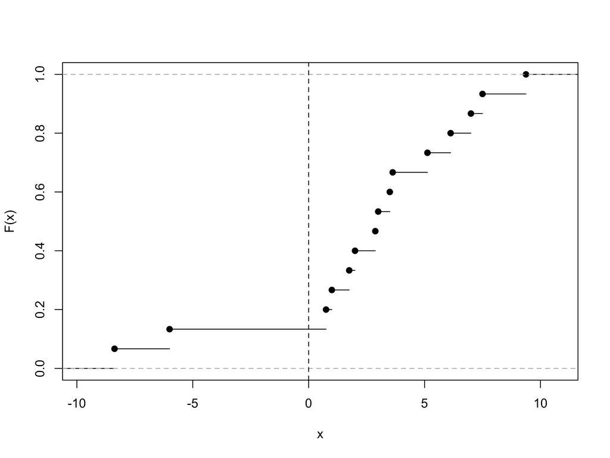

La linea verticale tratteggiata indica il valore della funzione di ripartizione valutata in $0$, ovvero $F(0)$:

```
## [1] 0.1333333
```

Di consequenza, la maggioranza delle piantine `cross`, ovvero circa l’$87\%$, assume valori maggiori di quelle `self`, dimostrando nuovamente una forte dipendenza. In altri termini, l’impollinazione incrociata sembra essere associata a piantine di maggior vigore.

## Problema 2

Si vuole analizzare la potenzialità di un fertilizzante nel velocizzare la crescita degli alberi. Per $n = 10$ alberi si rileva la quantità di `fertilizzante` che è stata usata nel terreno su cui ciascun alberto è stato coltivato, espressa in mg per g, e la velocità di `crescita` dell’albero, in cm al mese. Le osservazioni sono riportate nella tabella seguente.

| `fertilizzante` | `crescita` |
| --- | --- |
| 8.31 | 7.51 |
| 9.15 | 9.04 |
| 7.77 | 6.64 |
| 4.39 | 4.65 |
| 0.31 | 1.85 |
| 8.94 | 8.37 |
| 5.13 | 5.10 |
| 1.39 | 2.61 |
| 4.30 | 6.01 |
| 2.03 | 4.30 |

1. Si rappresentino graficamente le variabili `fertilizzante` e `crescita` tramite un diagramma a dispersione.
2. Si specifichi un modello di regressione per studiare la `crescita` media in funzione della quantità di `fertilizzante`. Si stimi tale modello.
3. Si ottenga un indice di bontà d’adattamento per il modello stimato al punto precedente. Si ottenga inoltre la varianza residuale di tale modello.
4. La crescita media aumenta con la quantità di fertilizzante? Si **argomenti**, basandosi sui risultati ottenuti ai punti precedenti.
5. Si dica qual è la crescita media in assenza di fertilizzante. Inoltre, quanto fertilizzante è necessario affinchè la crescita media sia pari a $5$cm al mese?

**Schema della soluzione**

Grafico a dispersione (richiesto), con retta di regressione stimata (non richiesta)

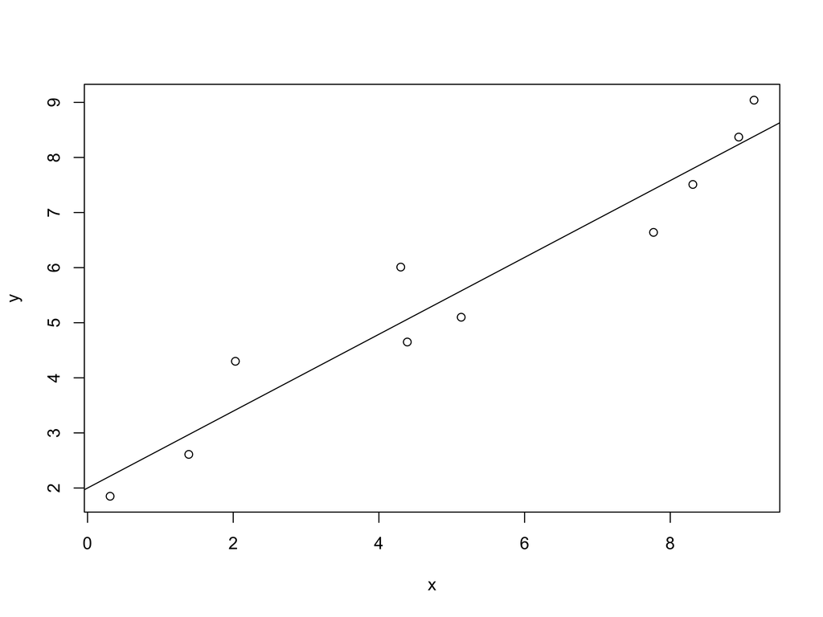

Alcune utili statistiche descrittive preliminari:

```
##      Media fert. Media crescita Varianza fert. Varianza crescita Covarianza Correlazione
## [1,]       5.172          5.608       9.580736          5.024876   6.684884    0.9634557
```

Coefficienti del modello di regressione stimati $(\hat{\alpha},\hat{\beta})$:

```
## (Intercept)           x
##   1.9992772   0.6977422
```

Indice $R^2$ e varianza residuale:

```
## [1] 0.9282469 0.3605502
```

La quantità fertilizzante sembra pertanto comportare un aumento della crescita. Ciò si deduce dal fatto che il coefficiente $\hat{\beta}$ calcolato in precedenza è positivo, congiuntamente al fatto che il coefficiente di correlazione $\rho$ è grande e positivo.

Si noti il valore di $R^2$, da solo, non consente di stabilire se esiste una relazione positiva o negativa tra le due variabili.

Previsione della crescita quando $x = 0$ coincide con $\hat{\alpha}$, ovvero:

```
## (Intercept)
##    1.999277
```

Valore del fertilizzante tale per cui la crescita è pari a $5$:

```
## (Intercept)
##    4.300618
```

## Problema 3

Si risponda a **tutti** i seguenti quesiti di carattere **teorico**.

1. Dopo averne dato la definizione, si **dimostri** che la media geometrica $\mathbb{G}$ di un insieme di dati $x_1,\dots,x_n$ a valori strettamente positivi è minore o uguale della loro media aritmetica $\bar{x}$. Si menzionino esplicitamente i risultati teorici utilizzati nella dimostrazione.
2. Si enunci e si **dimostri** il teorema di scomposizione della devianza.
3. Nel contesto delle tabelle di contingenza, si **dimostri** che le seguenti formule del $\chi^2$ sono equivalenti:

$$\chi^2 = \sum_{i=1}^h\sum_{j=1}^k \frac{(n_{ij} - \hat{n}_{ij})^2}{\hat{n}_{ij}} = n\left[\sum_{i=1}^h\sum_{j=1}^k\left(\frac{f_{ij}^2}{f_{i+}f_{+j}}\right) - 1\right].$$

La soluzione di questi esercizi è presente nelle slides oppure è stata spiegata in classe.